# Week 6: Quantitative analysis

Dani Cosme

2021-04-16

# resources

Here are a number of helpful resources to dig deeper into quantitative analysis:

**UO boot camp modules**

- [Data Wrangling with `{dplyr}`](https://uopsych-r-bootcamp-2020.netlify.app/post/07-dplyr/)

**Stats resources**

- [Quantitative Research Methods for Political Science, Public Policy and Public Administration for Undergraduates: 1st Edition With Applications in R](https://bookdown.org/wwwehde/qrm_textbook_updates/) by Wesley Wehde, Hank Jenkins-Smith, Joseph Ripberger, Gary Copeland, Matthew Nowlin, Tyler Hughes, Aaron Fister, and Josie Davis
- [Learning statistics with R: A tutorial for psychology students and other beginners](https://learningstatisticswithr.com/lsr-0.6.pdf) by Danielle Navarro

**Cheat sheets**

- [Data transformation with dplyr](https://github.com/rstudio/cheatsheets/raw/master/data-transformation.pdf)
- [Data tidying tidyr/readr](https://github.com/rstudio/cheatsheets/raw/master/data-transformation.pdf)
- [Data visualization](https://github.com/rstudio/cheatsheets/raw/master/data-visualization-2.1.pdf)
- [More useful cheat sheets!](https://www.rstudio.com/resources/cheatsheets/)

# load packages

```r
if (!require(pacman)) {
  install.packages("pacman")
}
pacman::p_load("tidyverse", "here", "sysfonts", install = TRUE)
```

# load the data file

Modify the path as needed to where your `week4_data.csv` file is downloaded. Note, my path is a little different, but for you, it should be in the `data/` directory in the same folder as this script.

Import the csv file and assign it to the variable `data`

```r
data = read_csv(here("static", "labs", "data", "week4_data.csv"))
```

# tidy the data using code from week 4

In week 4, we did most of these steps independently. Here, we’ll use `%>%` to thread the processes together without assigning any intermediate variables.

```r
data_tidy = data %>%
  # filter out test and incomplete responses
  filter(!DistributionChannel == "preview") %>%
  filter(Finished == 1 & consent == 1) %>%
  # select a subset of variables
  select(ResponseId, behavior_voting, reasons_yes,
         starts_with("CE_attitudes"), contains("checklist"), contains("pol_eff")) %>%
  # convert to long format
  pivot_longer(cols = -c(ResponseId, behavior_voting, reasons_yes), names_to = "scale_name") %>%
  # extract item number from scale_name
  extract(col = "scale_name", into = c("scale_name", "item"),
          regex = "(CE_attitudes|CE_checklist|pol_eff)_([0-9]+)") %>%
  # convert responses to numeric and recode response values
  mutate(value = as.numeric(value),
         value = ifelse(test = scale_name == "CE_checklist" & value == 2,
                        yes = 0,
                        no = value),
         behavior_voting = recode(behavior_voting,
                                  "1" = "yes",
                                  "2" = "no")) %>%
  # calculate scale means or sums for each participant
  group_by(ResponseId, scale_name) %>%
  mutate(summarized_value = ifelse(test = scale_name == "CE_checklist",
                                   yes = sum(value, na.rm = TRUE),
                                   no = mean(value, na.rm = TRUE))) %>%
  # remove the item and value columns
  select(-item, -value) %>%
  # remove repeated observations (rows)
  unique()
```

Let’s check out what the tidied data look like

```r
data_tidy
```

| ResponseId | behavior_voting | reasons_yes | scale_name | summarized_value |
| --- | --- | --- | --- | --- |
| R_3Gp961UT9BNkxCF | yes | 1,2,3,6,7,8,10,11,12,15,16 | CE_attitudes | 6.375 |
| R_3Gp961UT9BNkxCF | yes | 1,2,3,6,7,8,10,11,12,15,16 | CE_checklist | 4.000 |
| R_3Gp961UT9BNkxCF | yes | 1,2,3,6,7,8,10,11,12,15,16 | pol_eff | 6.500 |
| R_2abjLOinVp5zcvo | no | NA | CE_attitudes | 4.250 |
| R_2abjLOinVp5zcvo | no | NA | CE_checklist | 4.000 |
| R_2abjLOinVp5zcvo | no | NA | pol_eff | 3.000 |
| R_3lun7JrZiOjYkgo | yes | 1,7,8,9,10,11,12,14,15,16 | CE_attitudes | 5.750 |
| R_3lun7JrZiOjYkgo | yes | 1,7,8,9,10,11,12,14,15,16 | CE_checklist | 6.000 |
| R_3lun7JrZiOjYkgo | yes | 1,7,8,9,10,11,12,14,15,16 | pol_eff | 3.750 |
| R_40VV5bSVDU5LZL3 | no | NA | CE_attitudes | 5.625 |

[output cut: 488 more lines]

# descriptive stats

Descriptive stats describe different properties of the data. Here, we’ll focus on the following properties:

- Number of observations
- Counts and percentages
- Central tendencies (mean, median, mode)
- Response ranges
- Variance around the central tendency

## number of observations

Right now the data are in the long format. If we want to know the number of people who completed the survey, we have two options.

We can convert it to the wide format using `pivot_wider()` and `nrow`()` as follows:

```r
data_tidy %>%
  pivot_wider(names_from = scale_name, values_from = summarized_value) %>%
  nrow()
```

```
## [1] 166
```

Or, we can use `summarize()` to count the number of observation for each `scale_name` variable with the `n()` to get the size of each group

```r
data_tidy %>%
  group_by(scale_name) %>%
  summarize(n = n())
```

| scale_name | n |
| --- | --- |
| CE_attitudes | 166 |
| CE_checklist | 166 |
| pol_eff | 166 |

## counts

Let’s say we wanted to know the number of people who selected each reason for voting. We’ll use code from week 5 to tidy the data to be in the long format using the following code

```r
reason_text = read_csv(here("static", "labs", "data", "week4_data_reasons.csv"))

data_reasons = data_tidy %>%
  # select relevant variables
  ungroup() %>%
  select(ResponseId, reasons_yes) %>%
  # split the selected responses and convert to a single row per response
  mutate(reasons_yes = strsplit(gsub("[][\"]", "", reasons_yes), ",")) %>%
  unnest(reasons_yes) %>%
  # convert to numeric to facilitate joining
  mutate(reasons_yes = as.numeric(reasons_yes)) %>%
  # join with text
  left_join(., reason_text, by = "reasons_yes") %>%
  # remove missing responses and "other" responses
  filter(!is.na(text) & !text == "Other") %>%
  # get unique responses
  unique()
```

Take a look at the data

```r
data_reasons
```

| ResponseId | reasons_yes | text |
| --- | --- | --- |
| R_3Gp961UT9BNkxCF | 1 | It is my civic duty |
| R_3Gp961UT9BNkxCF | 2 | It’s part of being an adult |
| R_3Gp961UT9BNkxCF | 3 | To support my community |
| R_3Gp961UT9BNkxCF | 6 | To make my voice heard |
| R_3Gp961UT9BNkxCF | 7 | To hold politicians accountable |
| R_3Gp961UT9BNkxCF | 8 | To advance social justice |
| R_3Gp961UT9BNkxCF | 10 | Because it's my right |
| R_3Gp961UT9BNkxCF | 11 | To participate in democracy |
| R_3Gp961UT9BNkxCF | 12 | Because I care about the consequences of the election |
| R_3Gp961UT9BNkxCF | 15 | To express myself |

[output cut: 1911 more lines]

Next, we’ll use similar code as above to group by the `text` column and calculate the group size (count) for each reason

```r
data_reasons %>%
  group_by(text) %>%
  summarize(count = n())
```

| text | count |
| --- | --- |
| Because I am worried about my future | 98 |
| Because I care about the consequences of the election | 137 |
| Because it's my right | 125 |
| Because others do not want me to vote | 22 |
| Because the election outcome will affect me financially | 48 |
| Because there is a lot at stake this election | 132 |
| It is my civic duty | 138 |
| It’s part of being an adult | 120 |
| To advance social justice | 115 |
| To advocate for issues I care about | 125 |

[output cut: 8 more lines]

Right now the output is in alphabetical order by the text column. Let’s order by the count number using `arrange()`

```r
data_reasons %>%
  group_by(text) %>%
  summarize(count = n()) %>%
  arrange(count)
```

| text | count |
| --- | --- |
| Because others do not want me to vote | 22 |
| Because the election outcome will affect me financially | 48 |
| To support my family | 67 |
| To express myself | 81 |
| Because I am worried about my future | 98 |
| To be a part of something bigger than myself | 98 |
| To hold politicians accountable | 110 |
| To advance social justice | 115 |
| To build a better world | 118 |
| It’s part of being an adult | 120 |

[output cut: 8 more lines]

To change the order from ascending to descending, apply the `desc()` function to count

```r
data_reasons %>%
  group_by(text) %>%
  summarize(count = n()) %>%
  arrange(desc(count))
```

| text | count |
| --- | --- |
| It is my civic duty | 138 |
| Because I care about the consequences of the election | 137 |
| To participate in democracy | 135 |
| Because there is a lot at stake this election | 132 |
| To make my voice heard | 132 |
| Because it's my right | 125 |
| To advocate for issues I care about | 125 |
| It’s part of being an adult | 120 |
| To support my community | 120 |
| To build a better world | 118 |

[output cut: 8 more lines]

## percentages

Instead of counts, let’s change this to be the percent of people who endorsed each reason.

We’ll do this by dividing the count by the total number of observations. We’ll use the same code as before to get the number of observations, but this time save it as a variable we can use with `summarize()`

```r
n_observations = data_tidy %>%
  pivot_wider(names_from = scale_name, values_from = summarized_value) %>%
  nrow()

data_reasons %>%
  group_by(text) %>%
  summarize(count = n(),
            percent = (count / n_observations) * 100)
```

| text | count | percent |
| --- | --- | --- |
| Because I am worried about my future | 98 | 59.03614 |
| Because I care about the consequences of the election | 137 | 82.53012 |
| Because it's my right | 125 | 75.30120 |
| Because others do not want me to vote | 22 | 13.25301 |
| Because the election outcome will affect me financially | 48 | 28.91566 |
| Because there is a lot at stake this election | 132 | 79.51807 |
| It is my civic duty | 138 | 83.13253 |
| It’s part of being an adult | 120 | 72.28916 |
| To advance social justice | 115 | 69.27711 |
| To advocate for issues I care about | 125 | 75.30120 |

[output cut: 8 more lines]

If we want to remove the count column, we can do this with `select()`

```r
data_reasons %>%
  group_by(text) %>%
  summarize(count = n(),
            percent = (count / n_observations) * 100) %>%
  select(-count)
```

| text | percent |
| --- | --- |
| Because I am worried about my future | 59.03614 |
| Because I care about the consequences of the election | 82.53012 |
| Because it's my right | 75.30120 |
| Because others do not want me to vote | 13.25301 |
| Because the election outcome will affect me financially | 28.91566 |
| Because there is a lot at stake this election | 79.51807 |
| It is my civic duty | 83.13253 |
| It’s part of being an adult | 72.28916 |
| To advance social justice | 69.27711 |
| To advocate for issues I care about | 75.30120 |

[output cut: 8 more lines]

To add a `%` after the value in the percent column, we can use `sprintf()` as follows

```r
data_reasons %>%
  group_by(text) %>%
  summarize(count = n(),
            percent = (count / n_observations) * 100) %>%
  select(-count) %>%
  mutate(percent = sprintf("%s%s", percent, "%"))
```

| text | percent |
| --- | --- |
| Because I am worried about my future | 59.0361445783133% |
| Because I care about the consequences of the election | 82.5301204819277% |
| Because it's my right | 75.3012048192771% |
| Because others do not want me to vote | 13.2530120481928% |
| Because the election outcome will affect me financially | 28.9156626506024% |
| Because there is a lot at stake this election | 79.5180722891566% |
| It is my civic duty | 83.1325301204819% |
| It’s part of being an adult | 72.289156626506% |
| To advance social justice | 69.2771084337349% |
| To advocate for issues I care about | 75.3012048192771% |

[output cut: 8 more lines]

Way too many decimal points!

Instead of using `%s`, we can specify the placeholder as a digit with 1 decimal point by using `%.1f`

```r
data_reasons %>%
  group_by(text) %>%
  summarize(count = n(),
            percent = (count / n_observations) * 100) %>%
  select(-count) %>%
  mutate(percent = sprintf("%.1f%s", percent, "%"))
```

| text | percent |
| --- | --- |
| Because I am worried about my future | 59.0% |
| Because I care about the consequences of the election | 82.5% |
| Because it's my right | 75.3% |
| Because others do not want me to vote | 13.3% |
| Because the election outcome will affect me financially | 28.9% |
| Because there is a lot at stake this election | 79.5% |
| It is my civic duty | 83.1% |
| It’s part of being an adult | 72.3% |
| To advance social justice | 69.3% |
| To advocate for issues I care about | 75.3% |

[output cut: 8 more lines]

## central tendencies

Next, turn back to our questionnaires in `data_tidy` and look at some statistics summarizing the average across participants for each scale

First, let’s look at the mean across participants

```r
data_tidy %>%
  group_by(scale_name) %>%
  summarize(mean = mean(summarized_value, na.rm = TRUE))
```

| scale_name | mean |
| --- | --- |
| CE_attitudes | 5.766566 |
| CE_checklist | 3.969880 |
| pol_eff | 3.816265 |

Next, let’s look at the median

```r
data_tidy %>%
  group_by(scale_name) %>%
  summarize(median = median(summarized_value, na.rm = TRUE))
```

| scale_name | median |
| --- | --- |
| CE_attitudes | 5.875 |
| CE_checklist | 3.500 |
| pol_eff | 3.750 |

Finally, let’s calculate the mode

```r
data_tidy %>%
  group_by(scale_name) %>%
  summarize(mode = mode(summarized_value))
```

| scale_name | mode |
| --- | --- |
| CE_attitudes | numeric |
| CE_checklist | numeric |
| pol_eff | numeric |

Hmm that’s not what we want. Looks like we need to either write our own function to calculate that, or use a function that someone else has written and shared in a library.

We’ll use the `Mode()` function from `{DescTools}` (thanks stackoverflow!)

```r
pacman::p_load("DescTools", install = TRUE)

data_tidy %>%
  group_by(scale_name) %>%
  summarize(mode = Mode(summarized_value))
```

| scale_name | mode |
| --- | --- |
| CE_attitudes | 7 |
| CE_checklist | 3 |
| pol_eff | 4 |

To understand what each of these stats are telling us about the central tendency, let’s plot the data.

First, we’ll save those summary stats in `central_tendencies` so that we can plot as a layer on top of the density plot we created in week 5. We need to have the same x-axis with the data in long format, so we’ll use `pivot_longer()` to do that

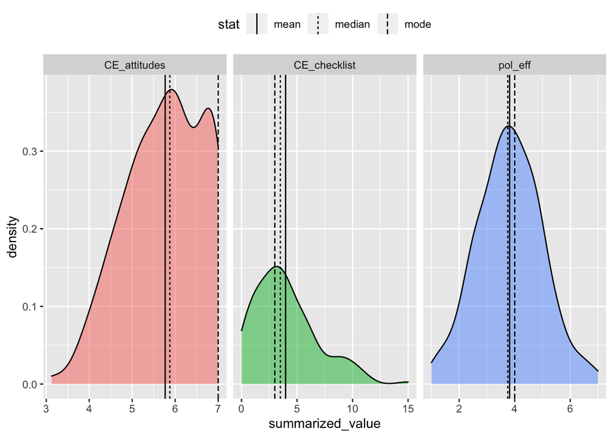

```r
central_tendencies = data_tidy %>%
  group_by(scale_name) %>%
  summarize(mean = mean(summarized_value, na.rm = TRUE),
            median = median(summarized_value, na.rm = TRUE),
            mode = Mode(summarized_value)) %>%
  pivot_longer(cols = c(mean, median, mode),
               names_to = "stat")


data_tidy %>%
  ggplot(aes(x = summarized_value)) +
  geom_density(aes(fill = scale_name), alpha = .5, show.legend = FALSE) +
  geom_vline(data = central_tendencies,
             aes(xintercept = value,
                 linetype = stat)) +
  facet_grid(~scale_name, scales = "free") +
  theme(legend.position = "top")
```

## range

Let’s check the range of values for each scale using `range()`

```r
data_tidy %>%
  group_by(scale_name) %>%
  summarize(range = range(summarized_value))
```

| scale_name | range |
| --- | --- |
| CE_attitudes | 3.125 |
| CE_attitudes | 7.000 |
| CE_checklist | 0.000 |
| CE_checklist | 15.000 |
| pol_eff | 1.000 |
| pol_eff | 7.000 |

```r
range(data_tidy$summarized_value)
```

```
## [1]  0 15
```

Let’s add a column to specify the min and max values, and then pivot to the wider format

```r
data_tidy %>%
  group_by(scale_name) %>%
  summarize(range = range(summarized_value)) %>%
  bind_cols(value = rep(c("min", "max"), 3)) %>%
  spread(value, range)
```

| scale_name | max | min |
| --- | --- | --- |
| CE_attitudes | 7 | 3.125 |
| CE_checklist | 15 | 0.000 |
| pol_eff | 7 | 1.000 |

## variance

Let’s characterize the distribution around the mean of each scale by calculating the standard deviation

```r
data_tidy %>%
  group_by(scale_name) %>%
  summarize(sd = sd(summarized_value, na.rm = TRUE))
```

| scale_name | sd |
| --- | --- |
| CE_attitudes | 0.9030192 |
| CE_checklist | 2.8378923 |
| pol_eff | 1.1570498 |

# inferential stats

We want to make inferences about the population and we do that by sampling from the population.

This section of [Quantitative Research Methods for Political Science, Public Policy and Public Administration for Undergraduates: 1st Edition With Applications in R](https://bookdown.org/wwwehde/qrm_textbook_updates/inference.html) provides some helpful background since we don’t have space to go into too much detail here.

## sampling

Let’s do a little simulation to learn about how sample size affects the sampling distribution.

We’re going to sample (with different sample sizes) from a uniform distribution, so we know that the true mean of the population = 0.5.

For each sample, we’ll calculate the mean, and repeat this 10,000 times and look at the different distributions this creates.

### run simulation

```r
# set the parameters
iter = 10000
sample_size = c(2, 5, 10, 25, 50, 100, 200, 400)

# create an empty matrix
sample_means = matrix(NA, nrow=iter, ncol=length(sample_size))

# run the simulation
for (a in 1:length(sample_size)) {
  b = sample_size[a]
  for (i in 1:iter) {
    sample = runif(b)
    sample_mean = mean(sample)
    sample_means[i,a] = sample_mean
  }
}
```

### plot means

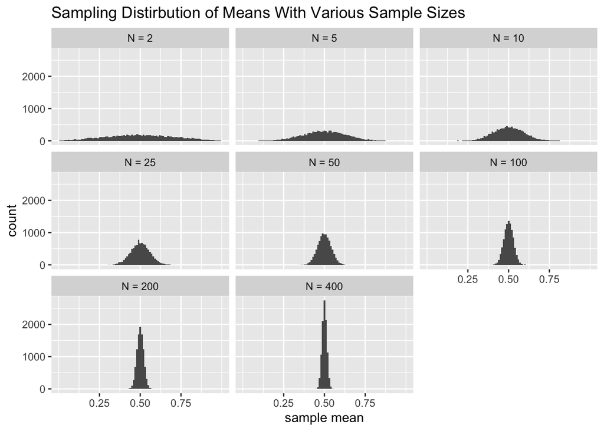

```r
# reshape data to long format
sample_means = as.data.frame(sample_means)
names(sample_means) = as.character(paste("N =", sample_size))

sample_means_long = sample_means %>%
  pivot_longer(cols = everything()) %>%
  extract(name, "order", "N = (.*)", remove = FALSE) %>%
  mutate(order = as.numeric(order))

# plot data
ggplot(sample_means_long, aes(value)) +
  geom_histogram(binwidth = 1/100) +
  facet_wrap(~reorder(name, order)) +
  scale_x_continuous(breaks = c(.25, .5, .75)) +
  xlab("sample mean") +
  labs(title="Sampling Distirbution of Means With Various Sample Sizes")
```

We can see that we can recover the true mean (0.5) with each of the different sample sizes, but we have way more variability with small sample sizes, than with large ones.

That means, that if we have a small sample size, we may observe a sampling mean that is very different than the mean (e.g. mean = .1 or .9) by chance and if we’re not careful, we might draw the wrong conclusions about the population based on our sample.

## precision and confidence intervals

A confidence interval is a measure of uncertainty around the sampling mean. It gives us a range of values within which we can expect the means from repeated samples from the population to fall.

Check out [this section of the book](https://bookdown.org/wwwehde/qrm_textbook_updates/inference.html#confidence-intervals) for more background on confidence intervals.

Here’s how to calculate a 95% confidence interval using the `{Rmisc}` package

```r
#install.packages("Rmisc")

data_tidy %>%
  group_by(scale_name) %>%
  summarize(value = Rmisc::CI(summarized_value, ci = .95)) %>%
  bind_cols(stat = rep(c("upper", "mean", "lower"), 3)) %>%
  spread(stat, value)
```

| scale_name | lower | mean | upper |
| --- | --- | --- | --- |
| CE_attitudes | 5.628182 | 5.766566 | 5.904951 |
| CE_checklist | 3.534982 | 3.969880 | 4.404777 |
| pol_eff | 3.638951 | 3.816265 | 3.993579 |

Let’s plot the mean and confidence interval as a bar graph

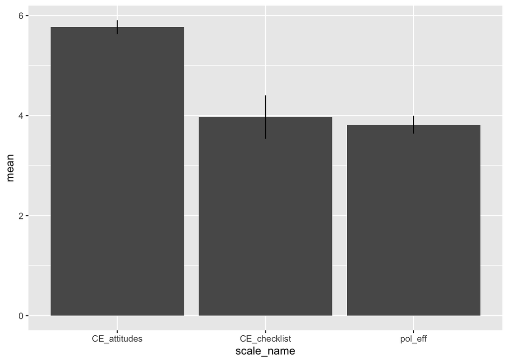

```r
data_tidy %>%
  group_by(scale_name) %>%
  summarize(value = Rmisc::CI(summarized_value)) %>%
  bind_cols(stat = rep(c("upper", "mean", "lower"), 3)) %>%
  spread(stat, value) %>%
  ggplot(aes(x = scale_name, y = mean)) +
  geom_bar(stat = "identity") +
  geom_linerange(aes(ymin = lower, ymax = upper))
```

We can also do this directly by using `stat_summary()`

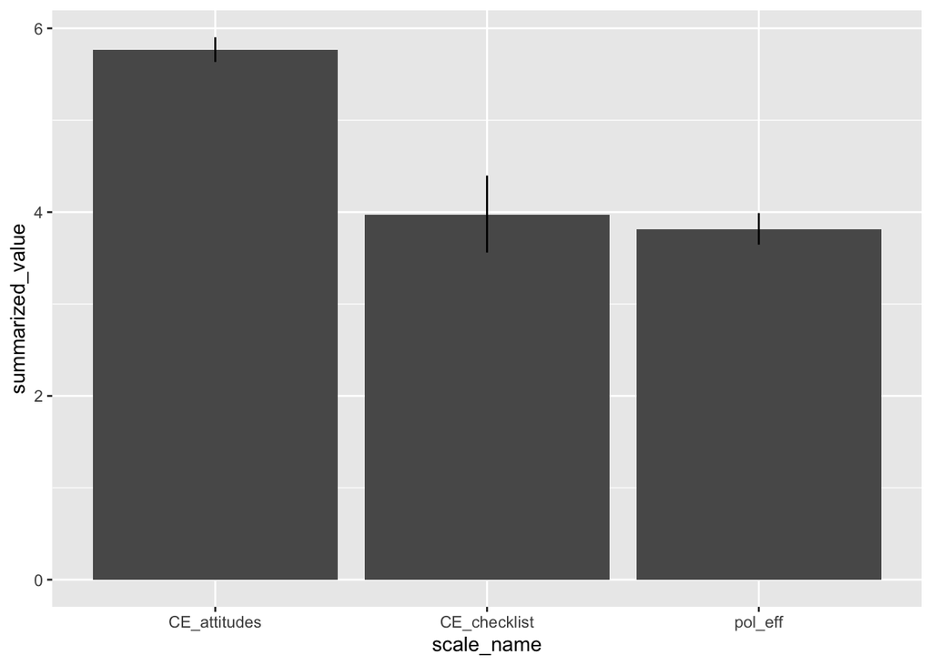

```r
data_tidy %>%
  ggplot(aes(x = scale_name, summarized_value)) +
  stat_summary(fun = "mean", geom = "bar", position = "dodge") +
  stat_summary(fun.data = "mean_cl_boot", geom = "errorbar", position = "dodge", width = 0) +
  theme(legend.position = "top")
```

## differences between group means

In week 5, we saw that the distributions for civic engagement attitudes looked like they might differ between folks who voted in the 2020 election and those who didn’t.

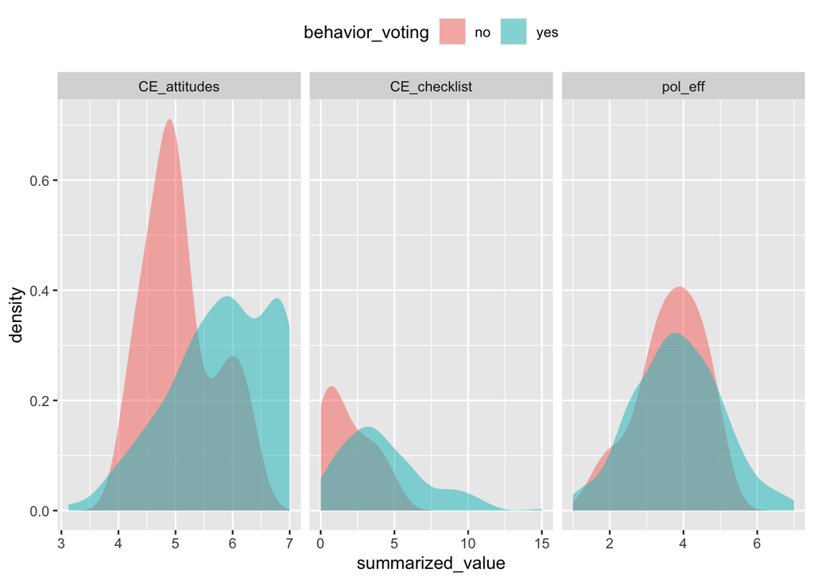

```r
data_tidy %>%
  ggplot(aes(x = summarized_value, fill = behavior_voting)) +
  geom_density(alpha = .5, color = NA) +
  facet_grid(~scale_name, scale = "free") +
  theme(legend.position = "top")
```

Now, let’s test whether the mean civic engagement attitudes differ by group. First, we’ll plot the means and 95% CIs

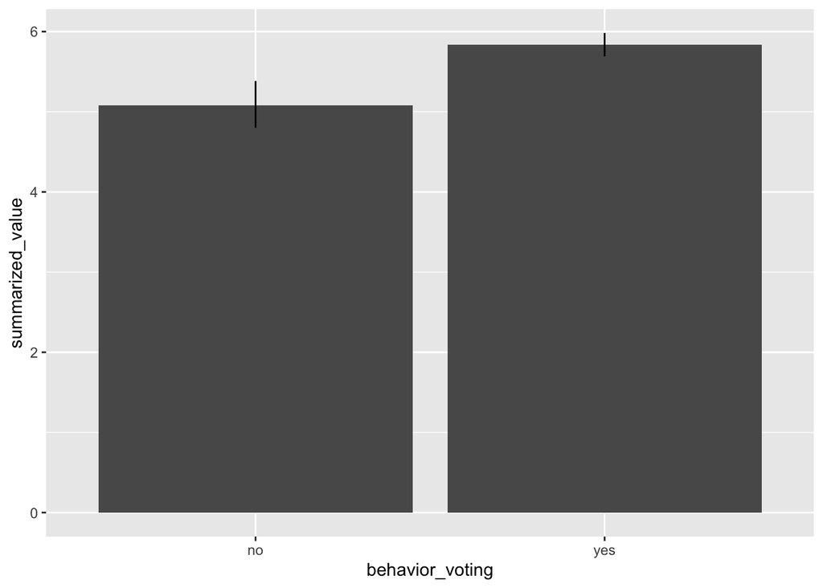

```r
data_tidy %>%
  filter(scale_name == "CE_attitudes") %>%
  ggplot(aes(x = behavior_voting, summarized_value)) +
  stat_summary(fun = "mean", geom = "bar", position = position_dodge(.9)) +
  stat_summary(fun.data = "mean_cl_boot", geom = "errorbar", position = position_dodge(.9),
               width = 0) +
  theme(legend.position = "top")
```

Now, let’s statistically test whether the difference between the means is different than 0 using a t-test.

Here’s the [relevant section in the book](https://bookdown.org/wwwehde/qrm_textbook_updates/inference.html#differences-between-groups) for more background about t-tests

```r
data_tidy %>%
  filter(scale_name == "CE_attitudes") %>%
  t.test(summarized_value ~ behavior_voting, data = .)
```

```
##
##  Welch Two Sample t-test
##
## data:  summarized_value by behavior_voting
## t = -4.2222, df = 20.208, p-value = 0.0004104
## alternative hypothesis: true difference in means is not equal to 0
## 95 percent confidence interval:
##  -1.1219400 -0.3802675
## sample estimates:
##  mean in group no mean in group yes
##          5.083333          5.834437
```

## associations between continuous variables

Next, we’ll look at how to test relationships between two continuous variables. Let’s look at the relationship between civic engagement attitudes and behaviors. Do people who have strong attitudes also tend to engage in more civic behaviors?

First, we’ll plot the data using a scatterplot

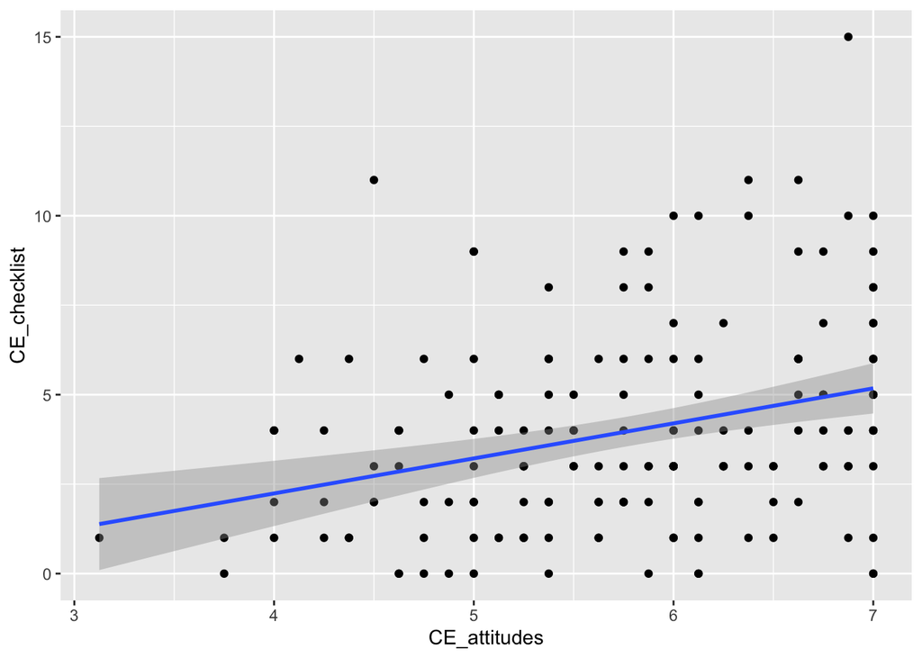

```r
data_tidy %>%
  spread(scale_name, summarized_value) %>%
  ggplot(aes(x = CE_attitudes, y = CE_checklist)) +
  geom_point() +
  geom_smooth(method = "lm") +
  theme(legend.position = "top")
```

Now, we’ll statistically test this relationship by calculating the strength of the correlation between the variables and testing whether that relationship is different than 0

```r
data_spread = data_tidy %>%
  spread(scale_name, summarized_value)

cor.test(data_spread$CE_attitudes, data_spread$CE_checklist)
```

```
##
##  Pearson's product-moment correlation
##
## data:  data_spread$CE_attitudes and data_spread$CE_checklist
## t = 4.1978, df = 164, p-value = 0.00004409
## alternative hypothesis: true correlation is not equal to 0
## 95 percent confidence interval:
##  0.1670895 0.4427961
## sample estimates:
##       cor
## 0.3114833
```

# assignment

Summarize the mean, median, mode, and number of observations for the three questionnaire scales

Plot the mean and 95% CIs for civic engagement behaviors as a function of voting behavior

Using a t-test, test whether mean civic engagement behavior statistically differ between people who voted and people who didn’t vote

Now, test whether mean political efficacy statistically differs between people who voted and people who didn’t vote

Using a scatterplot, visualize the relationship between civic engagement attitudes and political efficacy (`pol_eff`)

Test the correlation between civic engagement attitudes and political efficacy using the `data_spread` dataframe